# Explotació resultats simulació - BCN

IERMB

11 maig, 2021 - 15:34

Tots els resultats d’aquest document fan referència a la simulació amb dades per la ciutat de Barcelona. Les variables de rendes contemplen la transferència del IMV per les llars aplicables.

Referències simulació

| Variable | Valor |
| --- | --- |
| Territori | BCN |
| Escenari | U5 |
| n | 2514 |
| Iteracions | 1e+05 |
| Data simulació | 11/05/21 |
| Font dades atur | EPA 2020 |
| Referència temp. ERTOS | Desembre |
| Taxa d’atur projectada | 15.1 |
| Proporció atur amb prestació | 29.6 |
| Població afectada per ERTO | 28.3 |
| Assignació mesos a l’atur | probabilística |
| Base dades renda | EMCV |

### Taula 1.

Renda anual neta mitjana per llar, persona i unitat de consum (euros). Barcelona, 2016-2017, 2017-2018, 2018-2019 i estimacions 2020.

| Renda.anual.neta.mitjana | 16-17 | 17-18 | 18-19 | sim2020 |
| --- | --- | --- | --- | --- |
| per llar | 35605 | 36183 | 36331 | 33843.2 |
| per persona | 15140 | 15474 | 15594 | 14525.7 |
| per unitat de consum | 21926 | 22390 | 22567 | 20935.5 |

### Taula 2.

Variació relativa en la mitjana dels ingressos equivalents de la població segons decils de renda

| Decil | 2016-2017 | 2017-2018 | 2018-2019 | sim2020 | Variació |
| --- | --- | --- | --- | --- | --- |
| 1 | 5427.4 | 5238.2 | 4577.3 | 4439.6 | -3.0 |
| 2 | 9298.6 | 9353.4 | 9637.7 | 8186.4 | -15.1 |
| 3 | 12337.3 | 12672.7 | 12754.8 | 11433.3 | -10.4 |
| 4 | 14498.0 | 14920.4 | 15560.6 | 14048.8 | -9.7 |
| 5 | 17128.3 | 17610.0 | 18224.6 | 16178.3 | -11.2 |
| 6 | 20393.4 | 20651.0 | 20443.9 | 19421.2 | -5.0 |
| 7 | 24436.7 | 24444.0 | 23793.4 | 22440.6 | -5.7 |
| 8 | 29243.1 | 29571.7 | 29001.5 | 27189.5 | -6.2 |
| 9 | 34809.7 | 35626.8 | 35857.7 | 34544.4 | -3.7 |
| 10 | 52390.8 | 54305.1 | 57423.8 | 51829.3 | -9.7 |

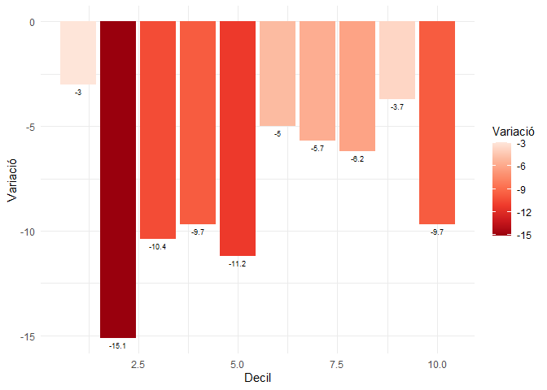

### Taula 3.1.

Índex de Gini

| Any | Valor | Sèrie |
| --- | --- | --- |
| 1985 | 39.8 | ECVHP |
| 1990 | 35.9 | ECVHP |
| 1995 | 33.9 | ECVHP |
| 2000 | 32.2 | ECVHP |
| 2006 | 30.8 | ECVHP |
| 2011 | 34.6 | ECVHP (base ECV 2004) |
| 16-17 | 33.4 | EMCV |
| 17-18 | 33.8 | EMCV |
| 18-19 | 34 | EMCV |
| sim2020 | 35 | Sim - EMCV |

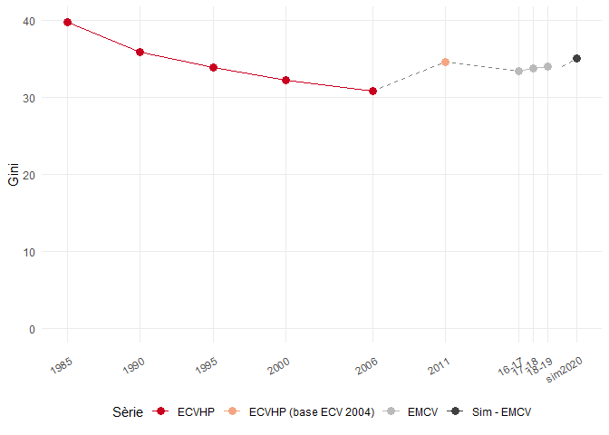

### Taula 3.2.

Raons de desigualtat entre decils de renda

| Raons | 2006 | 2011 | 16-17 | 17-18 | 18-19 | sim2020 |
| --- | --- | --- | --- | --- | --- | --- |
| P90/50 | 2.0 | 2.1 | 2.1 | 2.1 | 2.2 | 2.2 |
| P50/10 | 2.3 | 2.2 | 2.3 | 2.3 | 2.7 | 2.8 |

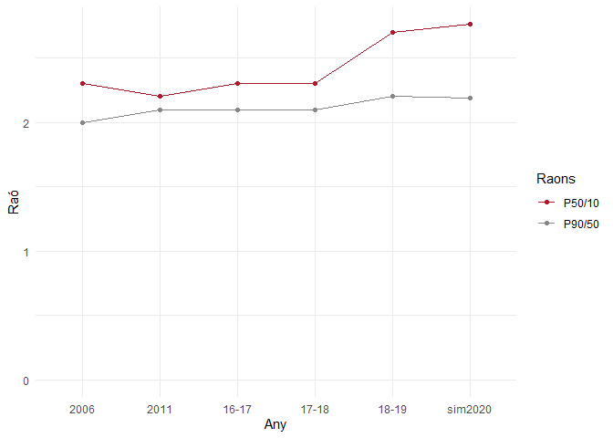

### Taula 4.1

Taxes de risc de pobresa segons intensitat

| indicador | 2011 | 16-17 | 17-18 | 18-19 | sim2020 |
| --- | --- | --- | --- | --- | --- |
| moderada (60%) | 24.1 | 21.3 | 21.6 | 21.0 | 22.5 |
| severa (40%) | 8.6 | 7.3 | 7.4 | 10.4 | 13.0 |
| extrema (30%) | 5.4 | 4.3 | 5.0 | 6.3 | 7.0 |

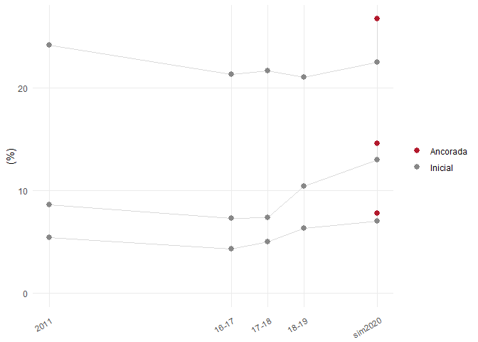

### Taula 4.2.

Intensitat de risc de pobresa

> % distance to poverty threshold: The indicator is calculated as the distance between the median equivalised total net income of persons below the at-risk-of-poverty threshold and the at-risk-of-poverty threshold itself, expressed as a percentage of the at-risk-of-poverty threshold. This threshold is set at 60 % of the national median equivalised disposable income of all people in a country and not for the EU as a whole.

| indicador | 2011 | 16-17 | 17-18 | 18-19 | sim2020 |
| --- | --- | --- | --- | --- | --- |
| Intensitat de risc de pobresa | 0.23 | 0.25 | 0.27 | 0.33 | 0.362 |
| Llindar | NA | NA | NA | NA | NA |
| Mediana IE pobres | NA | NA | NA | NA | NA |

### Taula 4.3

Pobresa ancorada (2018-2019) segons diferent intensitat. Llindar 2018-2019

| indicador | 2018-2019 | sim2020 |
| --- | --- | --- |
| Ancorada-Pobresa moderada (60% mediana) | 21.0 | 26.7 |
| Ancorada-Pobresa severa (40% mediana) | 10.4 | 14.6 |
| Ancorada-Pobresa extrema (30% mediana) | 6.3 | 7.8 |

### Taula 5.

Canvis a la pobresa estimada (60% mediana) segons característiques sociodemogràfiques

| var | categories | 17-18 | 18-19 | sim2020 | ANC2020 |
| --- | --- | --- | --- | --- | --- |
| sexe | Homes | 22.4 | 21.7 | 21.7 | 25.6 |
| sexe | Dones | 20.8 | 20.4 | 23.4 | 27.9 |
| edat | 0-17 anys | 30.8 | 30.4 | 34.2 | 40.8 |
| edat | 18-34 anys | 26.9 | 20.7 | 24.2 | 28.0 |
| edat | 35-64 anys | 18.2 | 19.6 | 21.0 | 24.8 |
| edat | 65 i més anys | 16.5 | 17.0 | 14.9 | 18.5 |
| nacionalitat | Espanya | 13.9 | 10.9 | 11.0 | 14.1 |
| nacionalitat | Resta del món | 41.6 | 41.7 | 45.1 | 51.2 |
| llars | Unipersonal < 65 anys | 19.2 | 26.6 | 27.4 | 32.5 |
| llars | Unipersonal > 65 anys | 26.1 | 28.2 | 24.8 | 28.2 |
| llars | sense infants | 13.3 | 13.4 | 14.6 | 16.8 |
| llars | amb infants | 31.3 | 27.6 | 30.2 | 36.6 |
| csp | Directius i professionals | 7.7 | 7.5 | 9.0 | 10.8 |
| csp | Ocupacions intermèdies | 11.0 | 9.5 | 8.9 | 12.7 |
| csp | Petits empresaris i autònoms | 32.3 | 31.2 | 27.9 | 35.9 |
| csp | semiqualificats de serveis | 27.3 | 25.5 | 26.4 | 30.7 |
| csp | semiqualificats o de rutina | 34.3 | 31.4 | 35.4 | 39.1 |
| csp | ALLD/NTM | 30.4 | 28.6 | 30.0 | 36.2 |

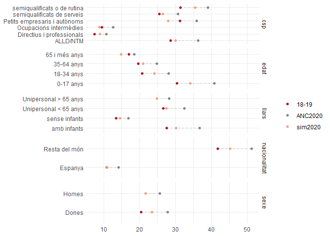

### Taula 6.

Proporció mitjana de la renda anual (neta) de les llars que es destina a les despeses fixes de l’habitatge (sense amortització), segons règim de tinença de l’habitatge.

| RTL | 2016-2017 | 2017-2018 | 2018-2019 | sim2020 |
| --- | --- | --- | --- | --- |
| Propietat totalment pagada | 10.6 | 10.3 | 9.6 | 10.0 |
| Propietat amb pagaments ajornats | 14.0 | 13.8 | 12.8 | 14.2 |
| En lloguer o relloguer | 39.0 | 39.4 | 40.5 | 45.0 |
| Un altre tipus de règim de tinença | 11.4 | 13.4 | 12.3 | 13.9 |
| Total | 21.6 | 22.5 | 23.1 | 25.4 |

### Taula 7.

Taxa de sobrecàrrega despeses habitatge (sense amortització) amb diferents llindars

| perc | RTL | 16-17 | 17-18 | 18-19 | sim2020 |
| --- | --- | --- | --- | --- | --- |
| >40% | pagada | 2.2 | 1.8 | 1.4 | 1.3 |
| >40% | pagaments | 3.0 | 4.2 | 2.1 | 3.1 |
| >40% | lloguer | 37.2 | 35.2 | 35.3 | 44.5 |
| >40% | altres | 2.4 | 2.5 | 3.7 | 5.4 |
| >60% | pagada | 1.5 | 1.1 | 0.7 | 0.6 |
| >60% | pagaments | 1.5 | 1.6 | 1.3 | 1.7 |
| >60% | lloguer | 14.3 | 16.7 | 18.3 | 20.9 |
| >60% | altres | 0.9 | 1.3 | 1.9 | 3.6 |

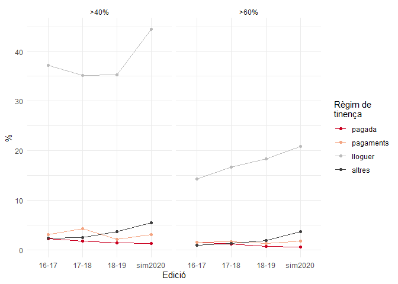

### Taula 8.

Taxa de risc de pobresa (60% mediana) abans i després del IMV

El llindar de referència fa servir les dades després de la injecció del IMV.

| TRP | abans | despres |
| --- | --- | --- |
| trp30 | 7.1 | 7.0 |
| trp40 | 13.0 | 13.0 |
| trp60 | 22.5 | 22.5 |